# Shoal Cohesion: Multilevel Meta-analysis

2025-12-14

# Purpose and scope

This report presents a multilevel meta-analysis of shoal cohesion across experimental categories. For each category, effects are synthesised using a multilevel REML model with random effects at the study and experiment levels.

# Results by category

## Category: Anxiolytics

### Overall effect

```
Multivariate Meta-Analysis Model (k = 14; method: REML)

Variance Components:

            estim    sqrt  nlvls  fixed           factor
sigma^2.1  0.0000  0.0001      7     no         study_id
sigma^2.2  0.0000  0.0000     10     no  study_id/exp_id

Test for Heterogeneity:
Q(df = 13) = 39.2439, p-val = 0.0002

Number of estimates:   14
Number of clusters:    7
Estimates per cluster: 1-4 (mean: 2.00, median: 2)

Model Results:

estimate      se¹     tval¹  df¹    pval¹    ci.lb¹   ci.ub¹
 -0.2675  0.1574   -1.6987    6   0.1403   -0.6527   0.1178

---
Signif. codes:  0 '***' 0.001 '**' 0.01 '*' 0.05 '.' 0.1 ' ' 1

1) results based on cluster-robust inference (var-cov estimator: CR1,
   approx t-test and confidence interval, df: residual method)
```

| category | estimate | ci_lb | ci_ub | p_value | sigma2_between | sigma2_within | k | n_studies |
| --- | --- | --- | --- | --- | --- | --- | --- | --- |
| Anxiolytics | -0.2675 | -0.6527 | 0.1178 | 0.1403 | 0 | 0 | 14 | 7 |

### Forest plot

**Caption.** Forest plot of individual effect sizes and the pooled multilevel estimate, including a prediction interval. **Interpretation.** The pooled summary represents the average effect; the prediction interval reflects the expected range of true effects in new studies given heterogeneity.

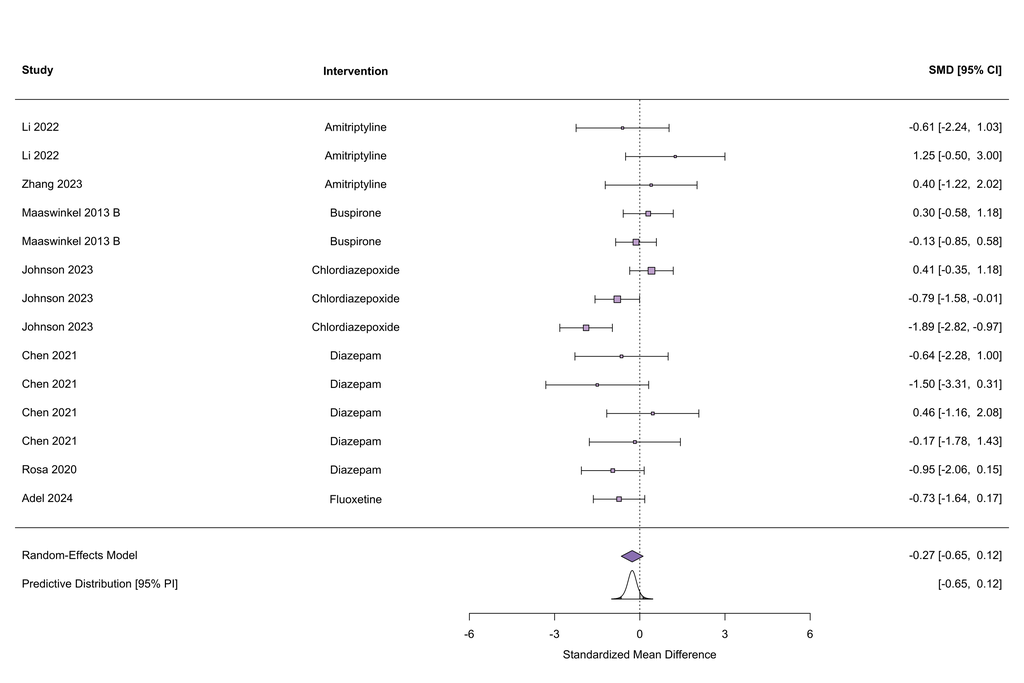

### Heterogeneity and variance decomposition

| category | I2_total | I2_between | I2_within |
| --- | --- | --- | --- |
| Anxiolytics | 0 | 0 | 0 |

**Interpretation.** I² quantifies the proportion of variability attributable to heterogeneity rather than sampling error, decomposed into between- and within-study components.

### Distribution of effects (orchard plot)

**Caption.** Orchard plot for the multilevel model for this category (PNG saved by the pipeline; colour scheme matches the original script). **Interpretation.** Orchard plots complement forest plots by visualising the distribution of effects with multilevel uncertainty and heterogeneity.

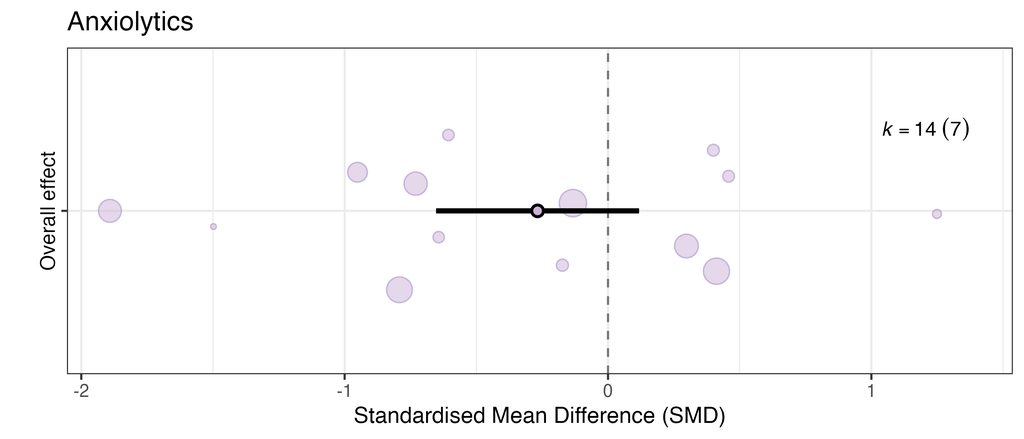

### Small-study effects and publication bias

#### Egger-type regressions

| category | slope_SE | p_SE | slope_SEeff | p_SEeff |
| --- | --- | --- | --- | --- |
| Anxiolytics | -0.4209 | 0.6613 | 0.4456 | 0.6759 |

**Interpretation.** The slope tests whether effect sizes are associated with sampling error (SE) or effective SE. Consistent significance may indicate small-study effects.

#### Funnel plot (Sampling Error)

**Caption.** Funnel plot using Sampling Error. **Interpretation.** Symmetry suggests little evidence of small-study effects; asymmetry suggests potential dissemination bias or related mechanisms.

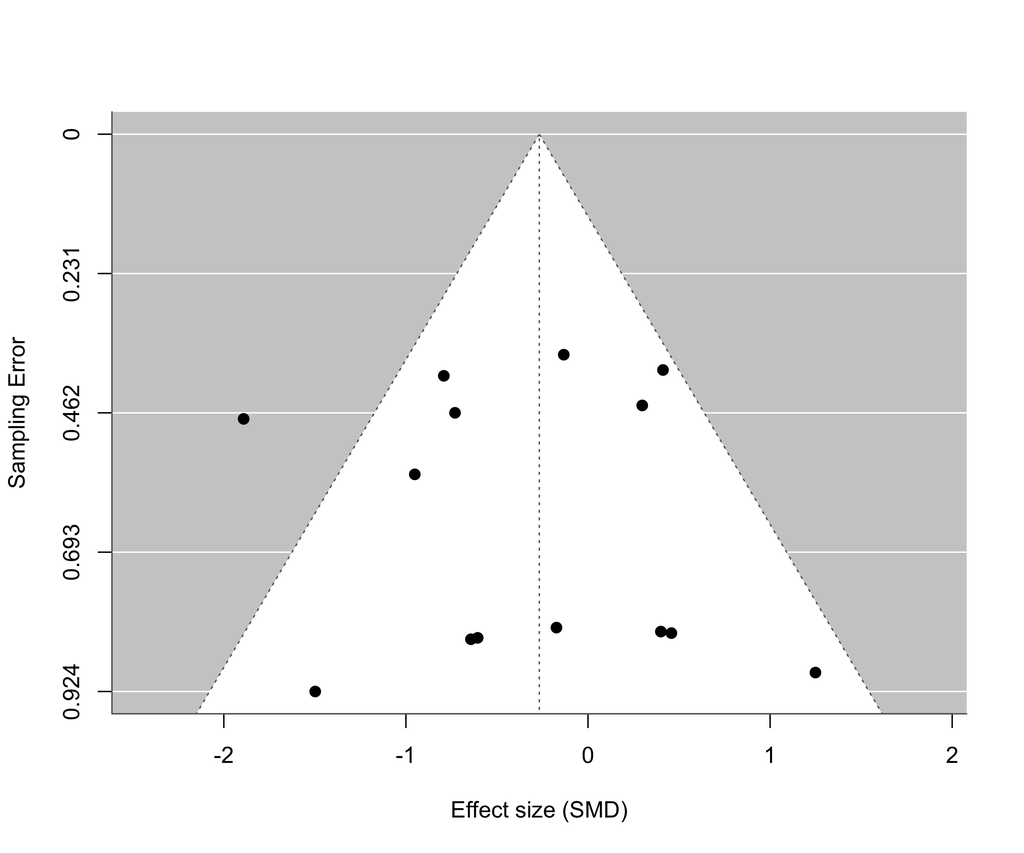

#### Funnel plot (precision = 1/√n)

**Caption.** Funnel plot using 1/√n as an alternative measure of precision. **Interpretation.** Agreement between the two funnel diagnostics strengthens inference about small-study effects.

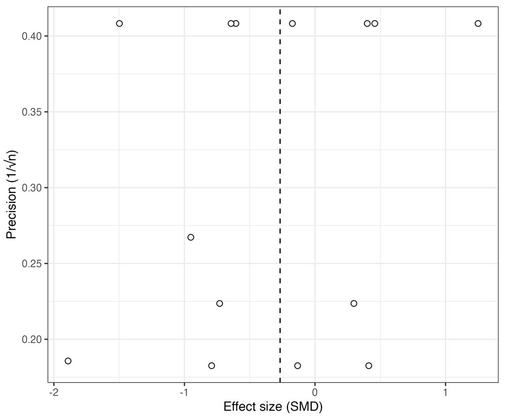

#### Bubble plot (Egger regression)

**Caption.** Bubble plot of effect sizes versus sampling error (SE), with study clustering. **Interpretation.** A visually non-zero slope is consistent with Egger regression evidence for small-study effects; a near-zero slope supports their absence.

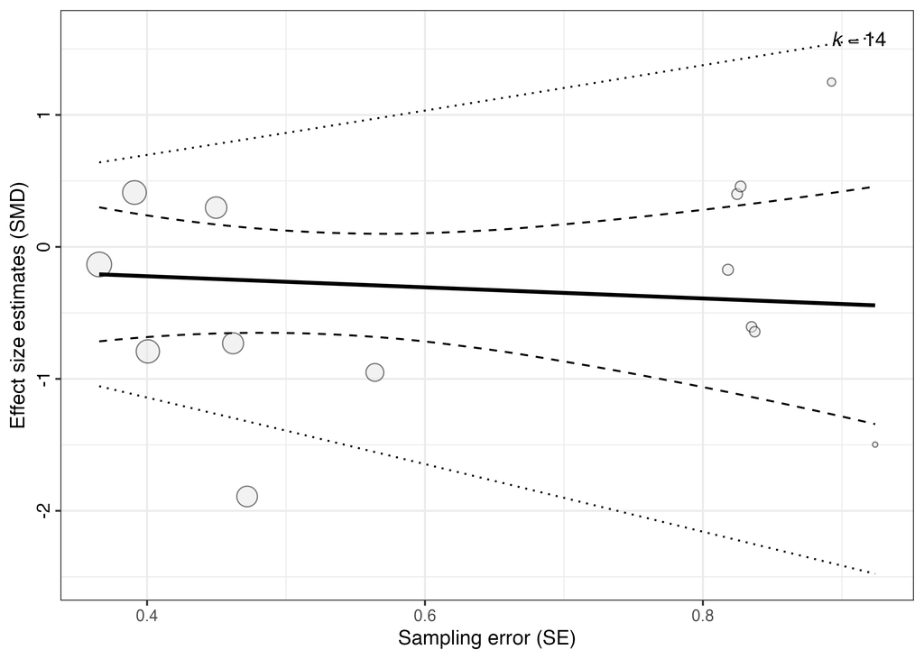

### Sensitivity analyses

#### 5.1 Leave-one-study-out

This analysis repeats the meta-analysis while removing one study at a time to assess influence. **Interpretation.** Large shifts in the pooled estimate indicate influential studies; stability indicates robustness.

| category | left_out | estimate | ci_lb | ci_ub | p_value | sigma2_between | sigma2_within | k | n_studies |
| --- | --- | --- | --- | --- | --- | --- | --- | --- | --- |
| Anxiolytics | Li_2022 | -0.3171 | -0.7572 | 0.1229 | 0.1231 | 0.0108 | 0 | 12 | 6 |
| Anxiolytics | Zhang_2023 | -0.3005 | -0.7298 | 0.1288 | 0.1319 | 0.0073 | 0 | 13 | 6 |
| Anxiolytics | Maaswinkel_2013_B | -0.4225 | -0.7803 | -0.0648 | 0.0289 | 0.0000 | 0 | 12 | 6 |
| Anxiolytics | Johnson_2023 | -0.2320 | -0.7307 | 0.2668 | 0.2854 | 0.0227 | 0 | 11 | 6 |
| Anxiolytics | Chen_2021 | -0.2613 | -0.7146 | 0.1920 | 0.1985 | 0.0157 | 0 | 10 | 6 |
| Anxiolytics | Rosa_2020 | -0.2038 | -0.5939 | 0.1862 | 0.2369 | 0.0000 | 0 | 13 | 6 |
| Anxiolytics | Adel_2024 | -0.2002 | -0.6025 | 0.2022 | 0.2571 | 0.0000 | 0 | 13 | 6 |

#### 5.2 Excluding high risk-of-bias studies

This analysis repeats the meta-analysis after excluding studies classified as high risk of bias. **Interpretation.** Differences from the main pooled effect indicate sensitivity to study quality; similar results suggest robustness.

| category | estimate | ci_lb | ci_ub | p_value | sigma2_between | sigma2_within | k | n_studies |
| --- | --- | --- | --- | --- | --- | --- | --- | --- |
| Anxiolytics | -0.2675 | -0.6527 | 0.1178 | 0.1403 | 0 | 0 | 14 | 7 |

#### Sensitivity to within-study correlation (rho)

This analysis varies the assumed within-study correlation among effect sizes. **Interpretation.** Stability of pooled estimates across rho values indicates robustness to assumptions about within-study dependence.

| category | rho | estimate | ci_lb | ci_ub | p_value | sigma2_between | sigma2_within | k | n_studies |
| --- | --- | --- | --- | --- | --- | --- | --- | --- | --- |
| Anxiolytics | 0.0 | -0.3643 | -0.7680 | 0.0394 | 0.0693 | 0.0372 | 0 | 14 | 7 |
| Anxiolytics | 0.2 | -0.3320 | -0.7343 | 0.0702 | 0.0899 | 0.0232 | 0 | 14 | 7 |
| Anxiolytics | 0.4 | -0.2925 | -0.6863 | 0.1013 | 0.1190 | 0.0080 | 0 | 14 | 7 |
| Anxiolytics | 0.5 | -0.2675 | -0.6527 | 0.1178 | 0.1403 | 0.0000 | 0 | 14 | 7 |
| Anxiolytics | 0.6 | -0.2417 | -0.6152 | 0.1319 | 0.1645 | 0.0000 | 0 | 14 | 7 |
| Anxiolytics | 0.8 | -0.1429 | -0.5199 | 0.2341 | 0.3895 | 0.0000 | 0 | 14 | 7 |

## Category: Ethanol

### Overall effect

```
Multivariate Meta-Analysis Model (k = 13; method: REML)

Variance Components:

            estim    sqrt  nlvls  fixed           factor
sigma^2.1  2.0344  1.4263      8     no         study_id
sigma^2.2  1.9956  1.4126      9     no  study_id/exp_id

Test for Heterogeneity:
Q(df = 12) = 122.5307, p-val < .0001

Number of estimates:   13
Number of clusters:    8
Estimates per cluster: 1-4 (mean: 1.62, median: 1)

Model Results:

estimate      se¹     tval¹  df¹    pval¹    ci.lb¹   ci.ub¹
 -0.6159  0.7393   -0.8330    7   0.4323   -2.3640   1.1323

---
Signif. codes:  0 '***' 0.001 '**' 0.01 '*' 0.05 '.' 0.1 ' ' 1

1) results based on cluster-robust inference (var-cov estimator: CR1,
   approx t-test and confidence interval, df: residual method)
```

| category | estimate | ci_lb | ci_ub | p_value | sigma2_between | sigma2_within | k | n_studies |
| --- | --- | --- | --- | --- | --- | --- | --- | --- |
| Ethanol | -0.6159 | -2.364 | 1.1323 | 0.4323 | 2.0344 | 1.9956 | 13 | 8 |

### Forest plot

**Caption.** Forest plot of individual effect sizes and the pooled multilevel estimate, including a prediction interval. **Interpretation.** The pooled summary represents the average effect; the prediction interval reflects the expected range of true effects in new studies given heterogeneity.

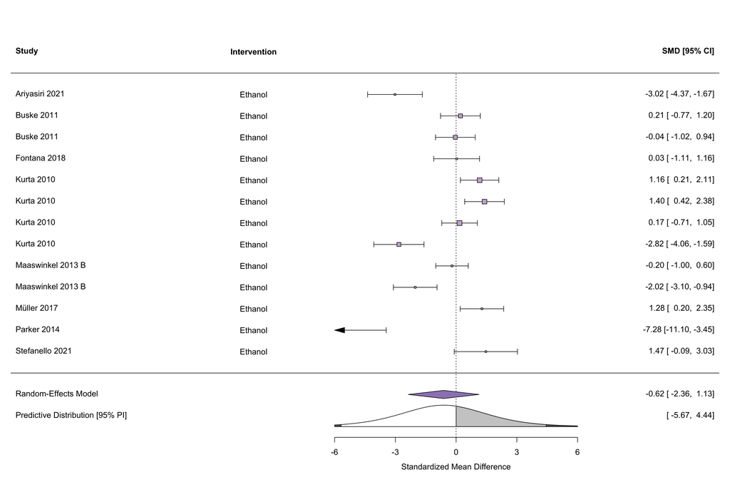

### Heterogeneity and variance decomposition

| category | I2_total | I2_between | I2_within |
| --- | --- | --- | --- |
| Ethanol | 92.965 | 46.931 | 46.034 |

**Interpretation.** I² quantifies the proportion of variability attributable to heterogeneity rather than sampling error, decomposed into between- and within-study components.

### Distribution of effects (orchard plot)

**Caption.** Orchard plot for the multilevel model for this category (PNG saved by the pipeline; colour scheme matches the original script). **Interpretation.** Orchard plots complement forest plots by visualising the distribution of effects with multilevel uncertainty and heterogeneity.

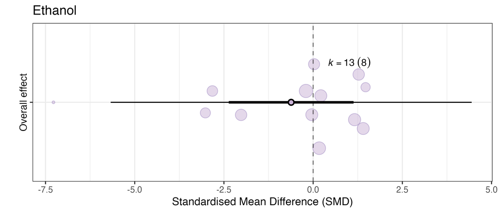

### Small-study effects and publication bias

#### Egger-type regressions

| category | slope_SE | p_SE | slope_SEeff | p_SEeff |
| --- | --- | --- | --- | --- |
| Ethanol | -10.2534 | 1e-04 | -6.7199 | 0.4573 |

**Interpretation.** The slope tests whether effect sizes are associated with sampling error (SE) or effective SE. Consistent significance may indicate small-study effects.

#### Funnel plot (Sampling Error)

**Caption.** Funnel plot using Sampling Error. **Interpretation.** Symmetry suggests little evidence of small-study effects; asymmetry suggests potential dissemination bias or related mechanisms.

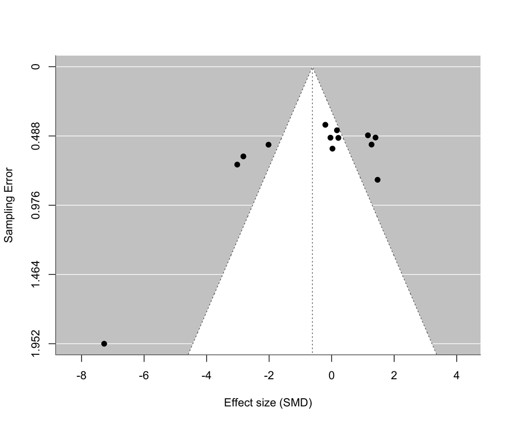

#### Funnel plot (precision = 1/√n)

**Caption.** Funnel plot using 1/√n as an alternative measure of precision. **Interpretation.** Agreement between the two funnel diagnostics strengthens inference about small-study effects.

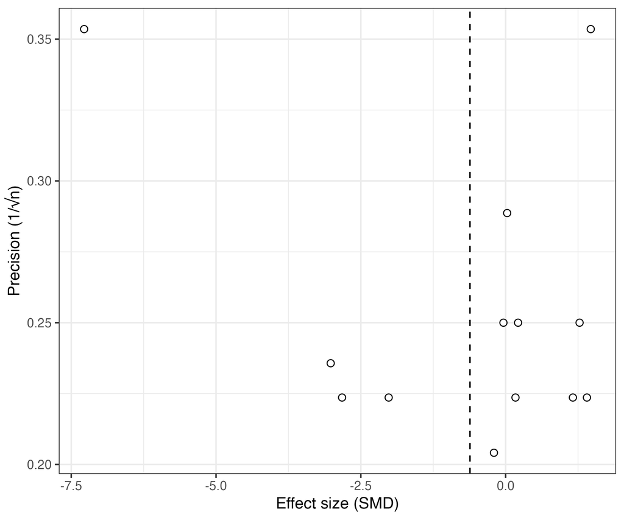

#### Bubble plot (Egger regression)

**Caption.** Bubble plot of effect sizes versus sampling error (SE), with study clustering. **Interpretation.** A visually non-zero slope is consistent with Egger regression evidence for small-study effects; a near-zero slope supports their absence.

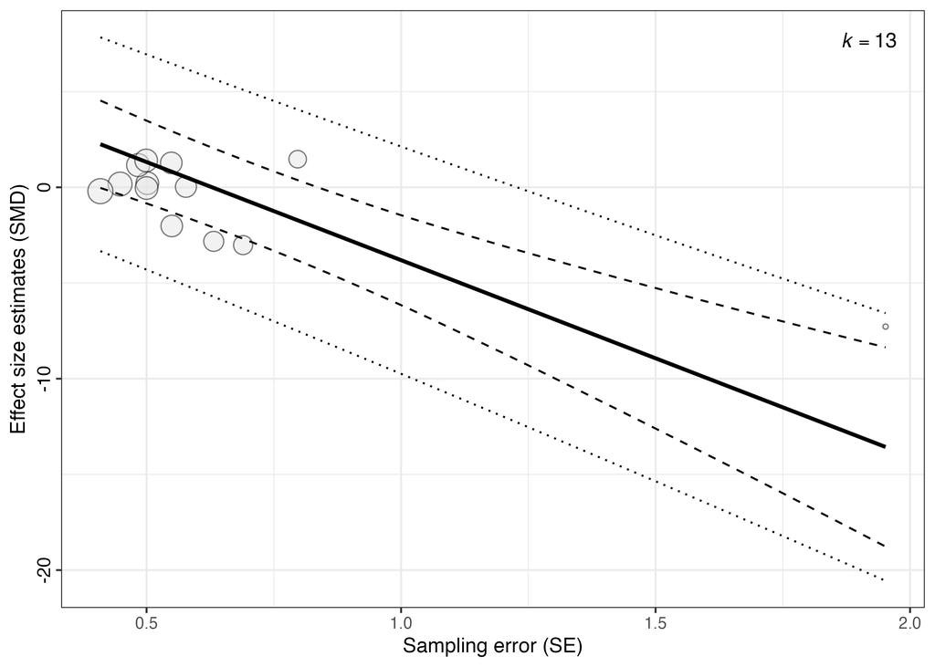

### Sensitivity analyses

#### 5.1 Leave-one-study-out

This analysis repeats the meta-analysis while removing one study at a time to assess influence. **Interpretation.** Large shifts in the pooled estimate indicate influential studies; stability indicates robustness.

| category | left_out | estimate | ci_lb | ci_ub | p_value | sigma2_between | sigma2_within | k | n_studies |
| --- | --- | --- | --- | --- | --- | --- | --- | --- | --- |
| Ethanol | Ariyasiri_2021 | -0.2240 | -1.8719 | 1.4240 | 0.7508 | 1.1112 | 1.7903 | 12 | 7 |
| Ethanol | Buske_2011 | -0.7768 | -3.0142 | 1.4606 | 0.4282 | 3.6521 | 1.7468 | 11 | 7 |
| Ethanol | Fontana_2018 | -0.7643 | -2.9962 | 1.4677 | 0.4342 | 3.6464 | 1.7463 | 12 | 7 |
| Ethanol | Kurta_2010 | -0.8656 | -3.0099 | 1.2787 | 0.3614 | 3.1231 | 1.8180 | 9 | 7 |
| Ethanol | Maaswinkel_2013_B | -0.5954 | -2.9125 | 1.7217 | 0.5527 | 2.8119 | 2.8119 | 11 | 7 |
| Ethanol | Müller_2017 | -0.9083 | -2.9266 | 1.1101 | 0.3130 | 2.4452 | 1.9479 | 12 | 7 |
| Ethanol | Parker_2014 | -0.1459 | -1.4779 | 1.1862 | 0.7977 | 0.4892 | 1.4821 | 12 | 7 |
| Ethanol | Stefanello_2021 | -0.9066 | -2.8822 | 1.0691 | 0.3044 | 2.2533 | 1.9998 | 12 | 7 |

#### 5.2 Excluding high risk-of-bias studies

This analysis repeats the meta-analysis after excluding studies classified as high risk of bias. **Interpretation.** Differences from the main pooled effect indicate sensitivity to study quality; similar results suggest robustness.

| category | estimate | ci_lb | ci_ub | p_value | sigma2_between | sigma2_within | k | n_studies |
| --- | --- | --- | --- | --- | --- | --- | --- | --- |
| Ethanol | -0.7643 | -2.9962 | 1.4677 | 0.4342 | 3.6464 | 1.7463 | 12 | 7 |

#### Sensitivity to within-study correlation (rho)

This analysis varies the assumed within-study correlation among effect sizes. **Interpretation.** Stability of pooled estimates across rho values indicates robustness to assumptions about within-study dependence.

| category | rho | estimate | ci_lb | ci_ub | p_value | sigma2_between | sigma2_within | k | n_studies |
| --- | --- | --- | --- | --- | --- | --- | --- | --- | --- |
| Ethanol | 0.0 | -0.6861 | -2.2361 | 0.8639 | 0.3300 | 0.0000 | 3.4998 | 13 | 8 |
| Ethanol | 0.2 | -0.6533 | -2.3333 | 1.0268 | 0.3884 | 1.5551 | 2.1965 | 13 | 8 |
| Ethanol | 0.4 | -0.6320 | -2.3517 | 1.0876 | 0.4136 | 1.8449 | 2.0630 | 13 | 8 |
| Ethanol | 0.5 | -0.6159 | -2.3640 | 1.1323 | 0.4323 | 2.0344 | 1.9956 | 13 | 8 |
| Ethanol | 0.6 | -0.5930 | -2.3823 | 1.1964 | 0.4589 | 2.2948 | 1.9217 | 13 | 8 |
| Ethanol | 0.8 | -0.4984 | -2.4828 | 1.4859 | 0.5712 | 3.4731 | 1.7336 | 13 | 8 |

## Category: NMDA antagonists

### Overall effect

```
Multivariate Meta-Analysis Model (k = 9; method: REML)

Variance Components:

            estim    sqrt  nlvls  fixed           factor
sigma^2.1  2.3314  1.5269      6     no         study_id
sigma^2.2  2.3314  1.5269      6     no  study_id/exp_id

Test for Heterogeneity:
Q(df = 8) = 86.6149, p-val < .0001

Number of estimates:   9
Number of clusters:    6
Estimates per cluster: 1-3 (mean: 1.50, median: 1)

Model Results:

estimate      se¹     tval¹  df¹    pval¹    ci.lb¹   ci.ub¹
 -2.1768  0.9658   -2.2538    5   0.0739   -4.6595   0.3060   .

---
Signif. codes:  0 '***' 0.001 '**' 0.01 '*' 0.05 '.' 0.1 ' ' 1

1) results based on cluster-robust inference (var-cov estimator: CR1,
   approx t-test and confidence interval, df: residual method)
```

| category | estimate | ci_lb | ci_ub | p_value | sigma2_between | sigma2_within | k | n_studies |
| --- | --- | --- | --- | --- | --- | --- | --- | --- |
| NMDA antagonists | -2.1768 | -4.6595 | 0.306 | 0.0739 | 2.3314 | 2.3314 | 9 | 6 |

### Forest plot

**Caption.** Forest plot of individual effect sizes and the pooled multilevel estimate, including a prediction interval. **Interpretation.** The pooled summary represents the average effect; the prediction interval reflects the expected range of true effects in new studies given heterogeneity.

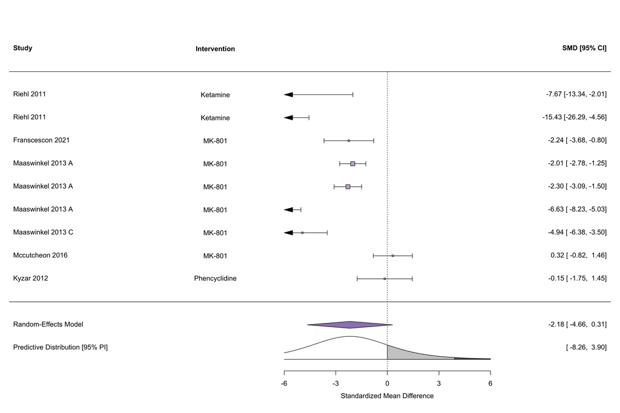

### Heterogeneity and variance decomposition

| category | I2_total | I2_between | I2_within |
| --- | --- | --- | --- |
| NMDA antagonists | 91.297 | 45.648 | 45.648 |

**Interpretation.** I² quantifies the proportion of variability attributable to heterogeneity rather than sampling error, decomposed into between- and within-study components.

### Distribution of effects (orchard plot)

**Caption.** Orchard plot for the multilevel model for this category (PNG saved by the pipeline; colour scheme matches the original script). **Interpretation.** Orchard plots complement forest plots by visualising the distribution of effects with multilevel uncertainty and heterogeneity.

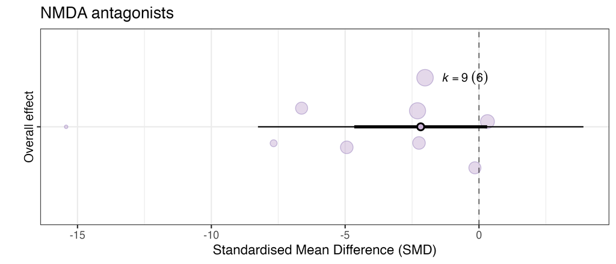

### Small-study effects and publication bias

#### Egger-type regressions

| category | slope_SE | p_SE | slope_SEeff | p_SEeff |
| --- | --- | --- | --- | --- |
| NMDA antagonists | -5.6967 | 7e-04 | -2.1004 | 0.7089 |

**Interpretation.** The slope tests whether effect sizes are associated with sampling error (SE) or effective SE. Consistent significance may indicate small-study effects.

#### Funnel plot (Sampling Error)

**Caption.** Funnel plot using Sampling Error. **Interpretation.** Symmetry suggests little evidence of small-study effects; asymmetry suggests potential dissemination bias or related mechanisms.

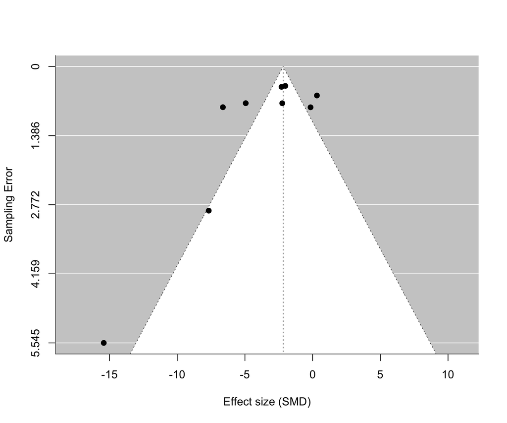

#### Funnel plot (precision = 1/√n)

**Caption.** Funnel plot using 1/√n as an alternative measure of precision. **Interpretation.** Agreement between the two funnel diagnostics strengthens inference about small-study effects.

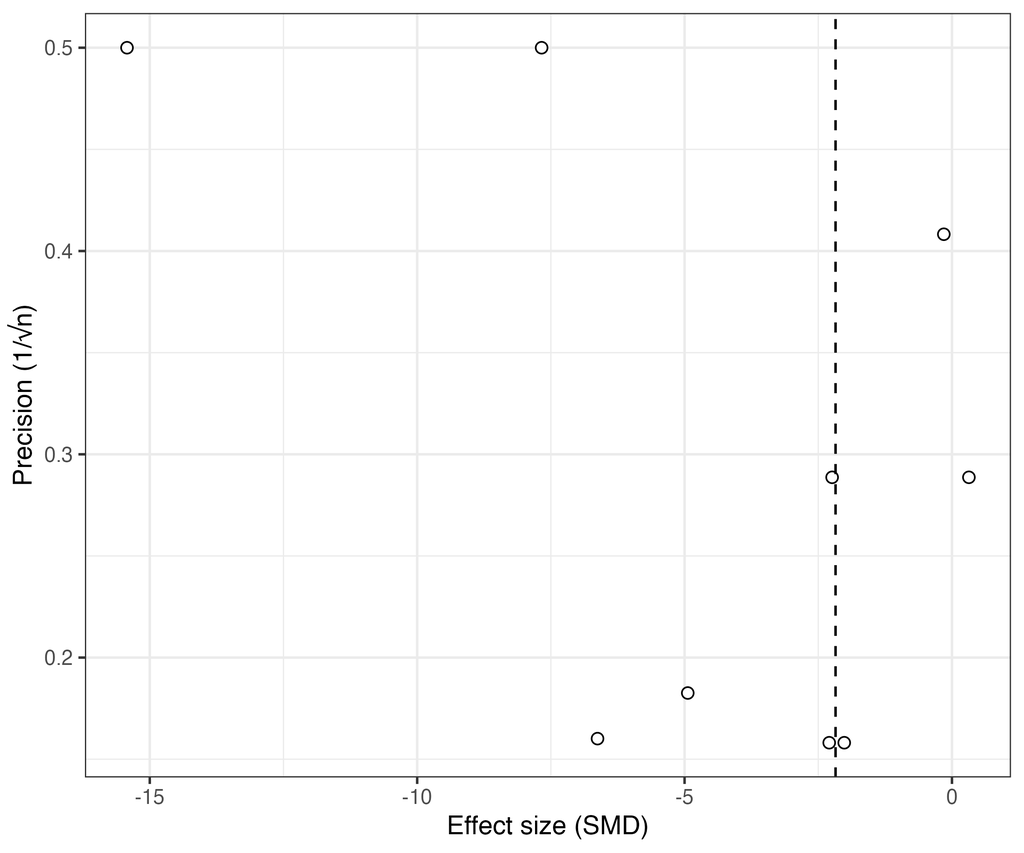

#### Bubble plot (Egger regression)

**Caption.** Bubble plot of effect sizes versus sampling error (SE), with study clustering. **Interpretation.** A visually non-zero slope is consistent with Egger regression evidence for small-study effects; a near-zero slope supports their absence.

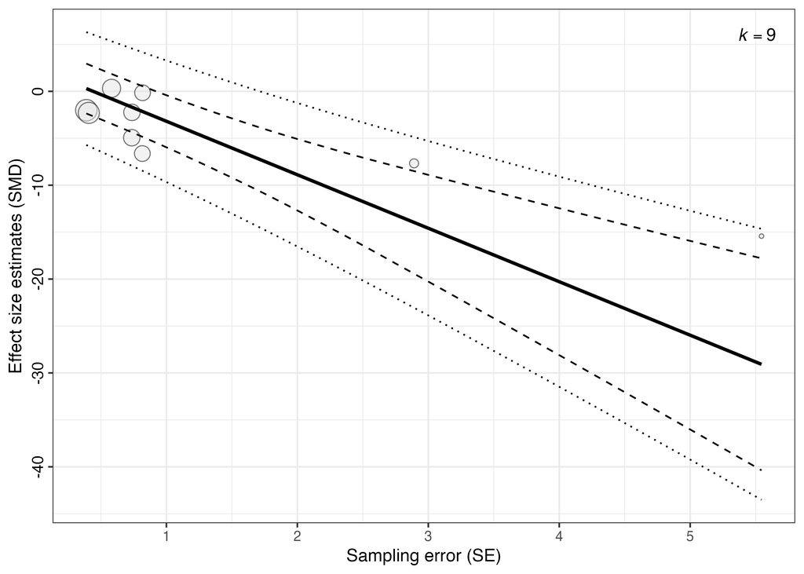

### Sensitivity analyses

#### 5.1 Leave-one-study-out

This analysis repeats the meta-analysis while removing one study at a time to assess influence. **Interpretation.** Large shifts in the pooled estimate indicate influential studies; stability indicates robustness.

| category | left_out | estimate | ci_lb | ci_ub | p_value | sigma2_between | sigma2_within | k | n_studies |
| --- | --- | --- | --- | --- | --- | --- | --- | --- | --- |
| NMDA antagonists | Riehl_2011 | -1.7352 | -4.2681 | 0.7978 | 0.1299 | 1.8663 | 1.8663 | 7 | 5 |
| NMDA antagonists | Franscescon_2021 | -2.2676 | -5.7361 | 1.2009 | 0.1437 | 3.3347 | 3.3347 | 8 | 5 |
| NMDA antagonists | Maaswinkel_2013_A | -2.3962 | -5.9139 | 1.1215 | 0.1316 | 3.3862 | 3.3862 | 6 | 5 |
| NMDA antagonists | Maaswinkel_2013_C | -1.2996 | -3.1833 | 0.5841 | 0.1279 | 0.8101 | 0.8101 | 8 | 5 |
| NMDA antagonists | Mccutcheon_2016 | -2.7274 | -5.5391 | 0.0842 | 0.0545 | 2.0604 | 2.0604 | 8 | 5 |
| NMDA antagonists | Kyzar_2012 | -2.6471 | -5.7536 | 0.4593 | 0.0772 | 2.6239 | 2.6239 | 8 | 5 |

#### 5.2 Excluding high risk-of-bias studies

This analysis repeats the meta-analysis after excluding studies classified as high risk of bias. **Interpretation.** Differences from the main pooled effect indicate sensitivity to study quality; similar results suggest robustness.

| category | estimate | ci_lb | ci_ub | p_value | sigma2_between | sigma2_within | k | n_studies |
| --- | --- | --- | --- | --- | --- | --- | --- | --- |
| NMDA antagonists | -2.1085 | -5.5019 | 1.2849 | 0.1424 | 2.0868 | 2.0868 | 6 | 4 |

#### Sensitivity to within-study correlation (rho)

This analysis varies the assumed within-study correlation among effect sizes. **Interpretation.** Stability of pooled estimates across rho values indicates robustness to assumptions about within-study dependence.

| category | rho | estimate | ci_lb | ci_ub | p_value | sigma2_between | sigma2_within | k | n_studies |
| --- | --- | --- | --- | --- | --- | --- | --- | --- | --- |
| NMDA antagonists | 0.0 | -2.6527 | -5.5791 | 0.2738 | 0.0672 | 3.4030 | 3.4030 | 9 | 6 |
| NMDA antagonists | 0.2 | -2.4717 | -5.1913 | 0.2479 | 0.0667 | 2.8737 | 2.8737 | 9 | 6 |
| NMDA antagonists | 0.4 | -2.2819 | -4.8333 | 0.2696 | 0.0699 | 2.4812 | 2.4812 | 9 | 6 |
| NMDA antagonists | 0.5 | -2.1768 | -4.6595 | 0.3060 | 0.0739 | 2.3314 | 2.3314 | 9 | 6 |
| NMDA antagonists | 0.6 | -2.0575 | -4.4841 | 0.3692 | 0.0812 | 2.2148 | 2.2148 | 9 | 6 |
| NMDA antagonists | 0.8 | -1.7209 | -4.1000 | 0.6583 | 0.1221 | 2.1358 | 2.1358 | 9 | 6 |

## Category: Stress

### Overall effect

```
Multivariate Meta-Analysis Model (k = 15; method: REML)

Variance Components:

            estim    sqrt  nlvls  fixed           factor
sigma^2.1  0.0000  0.0001     10     no         study_id
sigma^2.2  1.0124  1.0062     11     no  study_id/exp_id

Test for Heterogeneity:
Q(df = 14) = 73.1775, p-val < .0001

Number of estimates:   15
Number of clusters:    10
Estimates per cluster: 1-4 (mean: 1.50, median: 1)

Model Results:

estimate      se¹    tval¹  df¹    pval¹   ci.lb¹   ci.ub¹
  0.9412  0.3262   2.8854    9   0.0180   0.2033   1.6791   *

---
Signif. codes:  0 '***' 0.001 '**' 0.01 '*' 0.05 '.' 0.1 ' ' 1

1) results based on cluster-robust inference (var-cov estimator: CR1,
   approx t-test and confidence interval, df: residual method)
```

| category | estimate | ci_lb | ci_ub | p_value | sigma2_between | sigma2_within | k | n_studies |
| --- | --- | --- | --- | --- | --- | --- | --- | --- |
| Stress | 0.9412 | 0.2033 | 1.6791 | 0.018 | 0 | 1.0124 | 15 | 10 |

### Forest plot

**Caption.** Forest plot of individual effect sizes and the pooled multilevel estimate, including a prediction interval. **Interpretation.** The pooled summary represents the average effect; the prediction interval reflects the expected range of true effects in new studies given heterogeneity.

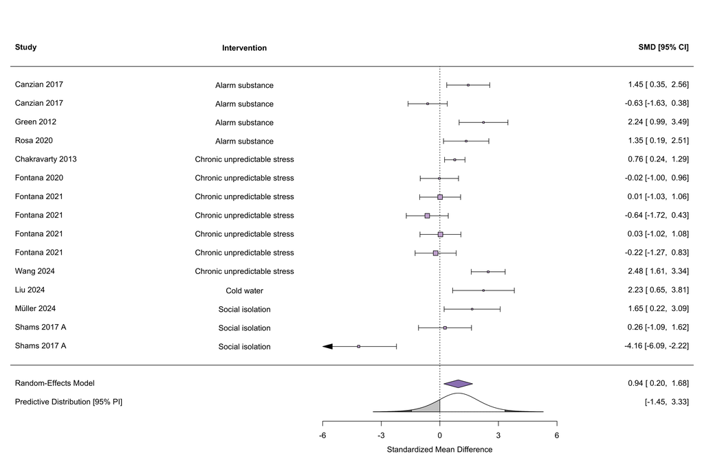

### Heterogeneity and variance decomposition

| category | I2_total | I2_between | I2_within |
| --- | --- | --- | --- |
| Stress | 78.222 | 0 | 78.222 |

**Interpretation.** I² quantifies the proportion of variability attributable to heterogeneity rather than sampling error, decomposed into between- and within-study components.

### Distribution of effects (orchard plot)

**Caption.** Orchard plot for the multilevel model for this category (PNG saved by the pipeline; colour scheme matches the original script). **Interpretation.** Orchard plots complement forest plots by visualising the distribution of effects with multilevel uncertainty and heterogeneity.

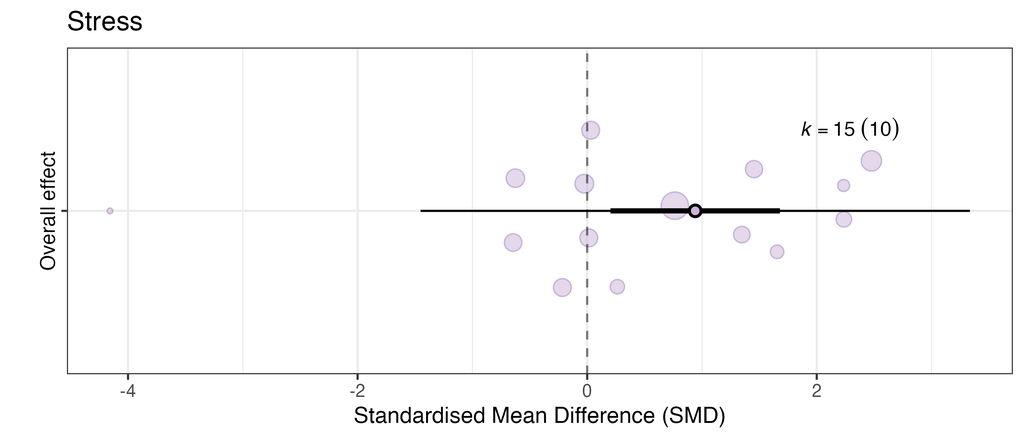

### Small-study effects and publication bias

#### Egger-type regressions

| category | slope_SE | p_SE | slope_SEeff | p_SEeff |
| --- | --- | --- | --- | --- |
| Stress | -9.9437 | 0.0013 | 15.4912 | 0.0051 |

**Interpretation.** The slope tests whether effect sizes are associated with sampling error (SE) or effective SE. Consistent significance may indicate small-study effects.

#### Funnel plot (Sampling Error)

**Caption.** Funnel plot using Sampling Error. **Interpretation.** Symmetry suggests little evidence of small-study effects; asymmetry suggests potential dissemination bias or related mechanisms.

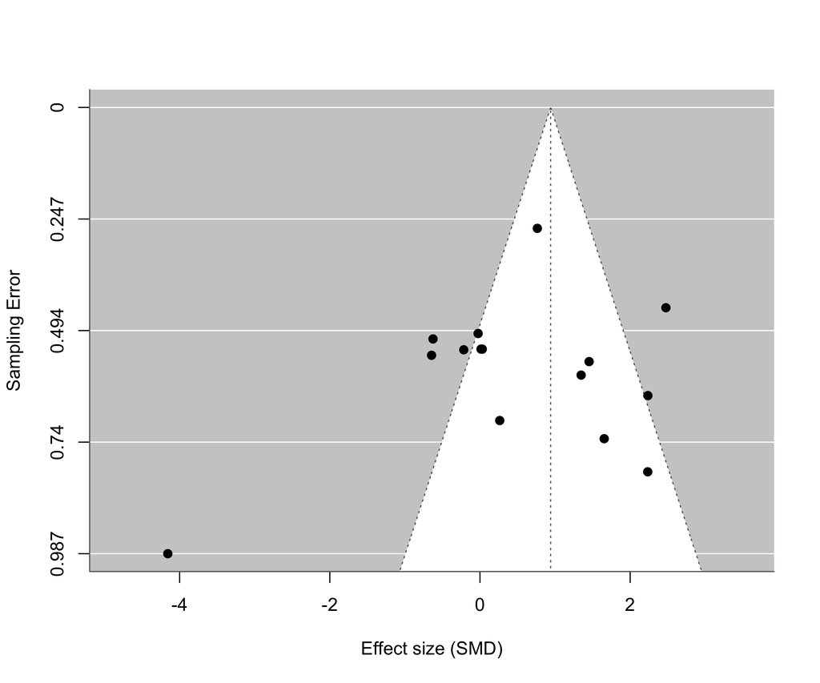

#### Funnel plot (precision = 1/√n)

**Caption.** Funnel plot using 1/√n as an alternative measure of precision. **Interpretation.** Agreement between the two funnel diagnostics strengthens inference about small-study effects.

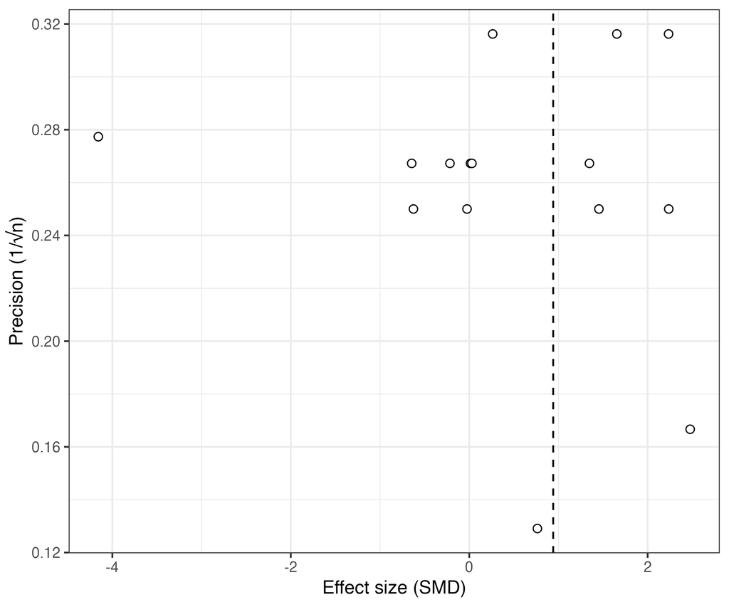

#### Bubble plot (Egger regression)

**Caption.** Bubble plot of effect sizes versus sampling error (SE), with study clustering. **Interpretation.** A visually non-zero slope is consistent with Egger regression evidence for small-study effects; a near-zero slope supports their absence.

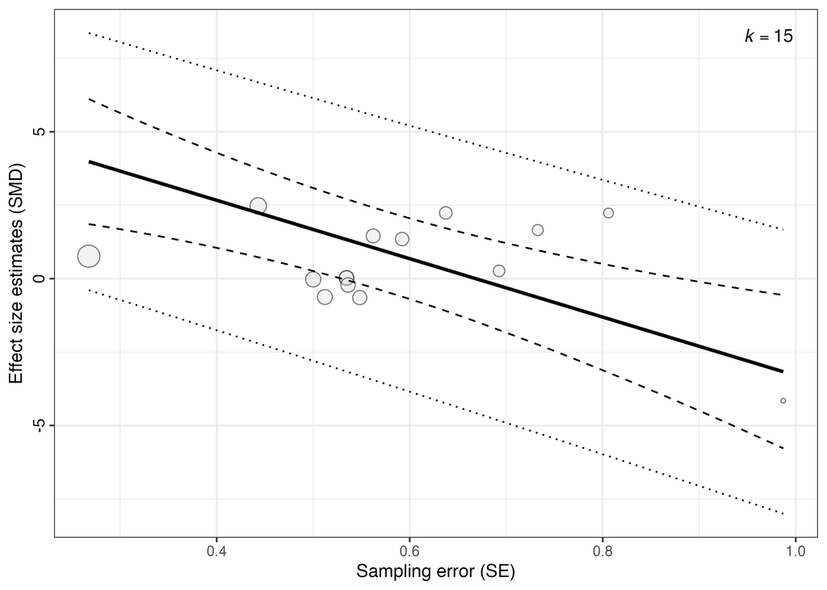

### Sensitivity analyses

#### 5.1 Leave-one-study-out

This analysis repeats the meta-analysis while removing one study at a time to assess influence. **Interpretation.** Large shifts in the pooled estimate indicate influential studies; stability indicates robustness.

| category | left_out | estimate | ci_lb | ci_ub | p_value | sigma2_between | sigma2_within | k | n_studies |
| --- | --- | --- | --- | --- | --- | --- | --- | --- | --- |
| Stress | Canzian_2017 | 1.0652 | 0.1901 | 1.9403 | 0.0230 | 0.4891 | 0.4891 | 13 | 9 |
| Stress | Green_2012 | 0.8197 | 0.0646 | 1.5747 | 0.0368 | 0.0000 | 0.9642 | 14 | 9 |
| Stress | Rosa_2020 | 0.9050 | 0.0836 | 1.7265 | 0.0347 | 0.0000 | 1.1348 | 14 | 9 |
| Stress | Chakravarty_2013 | 0.9676 | 0.1166 | 1.8185 | 0.0306 | 0.0000 | 1.1848 | 14 | 9 |
| Stress | Fontana_2020 | 1.0443 | 0.2373 | 1.8513 | 0.0175 | 0.0000 | 1.0487 | 14 | 9 |
| Stress | Fontana_2021 | 1.0677 | 0.2767 | 1.8588 | 0.0144 | 0.0000 | 0.9889 | 11 | 9 |
| Stress | Wang_2024 | 0.7593 | 0.0721 | 1.4464 | 0.0343 | 0.0000 | 0.7831 | 14 | 9 |
| Stress | Liu_2024 | 0.8398 | 0.0749 | 1.6047 | 0.0352 | 0.0000 | 0.9990 | 14 | 9 |
| Stress | Müller_2024 | 0.8826 | 0.0812 | 1.6840 | 0.0347 | 0.0000 | 1.0907 | 14 | 9 |
| Stress | Shams_2017_A | 1.0702 | 0.2996 | 1.8408 | 0.0126 | 0.0000 | 0.9507 | 13 | 9 |

#### 5.2 Excluding high risk-of-bias studies

This analysis repeats the meta-analysis after excluding studies classified as high risk of bias. **Interpretation.** Differences from the main pooled effect indicate sensitivity to study quality; similar results suggest robustness.

| category | estimate | ci_lb | ci_ub | p_value | sigma2_between | sigma2_within | k | n_studies |
| --- | --- | --- | --- | --- | --- | --- | --- | --- |
| Stress | 1.8658 | 0.4606 | 3.2709 | 0.0293 | 0 | 0 | 3 | 3 |

#### Sensitivity to within-study correlation (rho)

This analysis varies the assumed within-study correlation among effect sizes. **Interpretation.** Stability of pooled estimates across rho values indicates robustness to assumptions about within-study dependence.

| category | rho | estimate | ci_lb | ci_ub | p_value | sigma2_between | sigma2_within | k | n_studies |
| --- | --- | --- | --- | --- | --- | --- | --- | --- | --- |
| Stress | 0.0 | 0.8674 | 0.0588 | 1.6759 | 0.0382 | 0 | 1.2744 | 15 | 10 |
| Stress | 0.2 | 0.8904 | 0.1055 | 1.6754 | 0.0304 | 0 | 1.1830 | 15 | 10 |
| Stress | 0.4 | 0.9208 | 0.1652 | 1.6765 | 0.0222 | 0 | 1.0753 | 15 | 10 |
| Stress | 0.5 | 0.9412 | 0.2033 | 1.6791 | 0.0180 | 0 | 1.0124 | 15 | 10 |
| Stress | 0.6 | 0.9682 | 0.2504 | 1.6859 | 0.0138 | 0 | 0.9423 | 15 | 10 |
| Stress | 0.8 | 1.0766 | 0.3906 | 1.7627 | 0.0062 | 0 | 0.8191 | 15 | 10 |

# Combined orchard plots across all categories

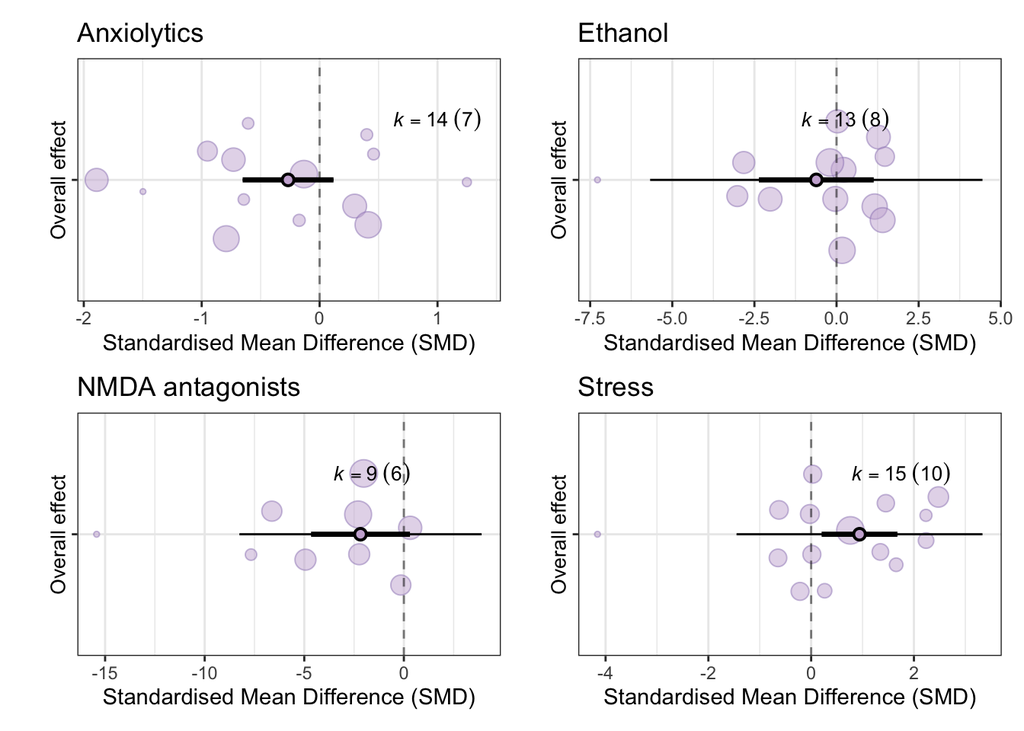

**Caption.** Combined orchard plots for all categories.  
**Interpretation.** This panel supports direct comparison of pooled effects and uncertainty across categories.

# Miscellaneous studies

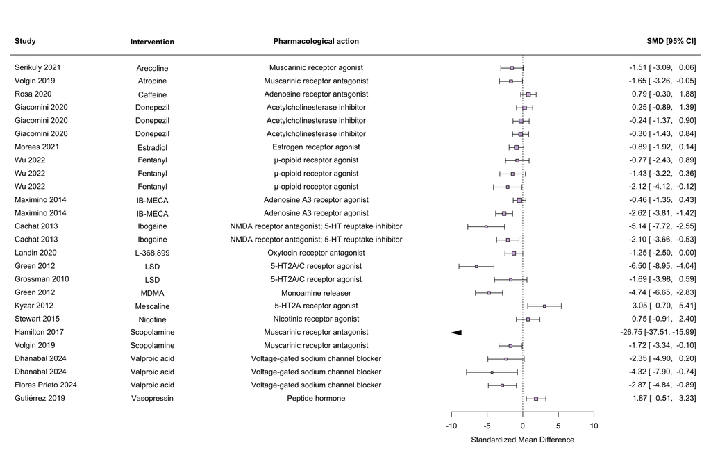

**Caption.** Forest plot for miscellaneous studies (descriptive fixed-effect display).  
**Interpretation.** Miscellaneous studies are shown descriptively and not pooled into the main multilevel models due to conceptual heterogeneity.

# Computational environment

R version: R version 4.5.1 (2025-06-13) Platform: Darwin / 24.5.0 / arm64 Render date: 2025-12-14

R version 4.5.1 (2025-06-13) Platform: aarch64-apple-darwin20 Running under: macOS Sequoia 15.5

Matrix products: default BLAS: /Library/Frameworks/R.framework/Versions/4.5-arm64/Resources/lib/libRblas.0.dylib LAPACK: /Library/Frameworks/R.framework/Versions/4.5-arm64/Resources/lib/libRlapack.dylib; LAPACK version 3.12.1

locale: [1] en_US.UTF-8/en_US.UTF-8/en_US.UTF-8/C/en_US.UTF-8/en_US.UTF-8

time zone: America/Sao_Paulo tzcode source: internal

attached base packages: [1] stats graphics grDevices utils datasets methods base

other attached packages: [1] patchwork_1.3.2 orchaRd_2.1.3 clubSandwich_0.6.1 metafor_4.8-0 numDeriv_2016.8-1.1 [6] metadat_1.4-0 Matrix_1.7-3 lubridate_1.9.4 forcats_1.0.0 stringr_1.5.2  
[11] dplyr_1.1.4 purrr_1.1.0 readr_2.1.6 tidyr_1.3.1 tibble_3.3.0  
[16] ggplot2_4.0.1 tidyverse_2.0.0

loaded via a namespace (and not attached): [1] beeswarm_0.4.0 gtable_0.3.6 xfun_0.53 bslib_0.9.0 lattice_0.22-7 mathjaxr_1.8-0  
[7] tzdb_0.5.0 vctrs_0.6.5 tools_4.5.1 generics_0.1.4 parallel_4.5.1 sandwich_3.1-1  
[13] pkgconfig_2.0.3 RColorBrewer_1.1-3 S7_0.2.0 lifecycle_1.0.4 compiler_4.5.1 farver_2.1.2  
[19] textshaping_1.0.4 codetools_0.2-20 vipor_0.4.7 htmltools_0.5.8.1 sass_0.4.10 yaml_2.3.10  
[25] pillar_1.11.1 crayon_1.5.3 jquerylib_0.1.4 MASS_7.3-65 cachem_1.1.0 multcomp_1.4-28  
[31] nlme_3.1-168 tidyselect_1.2.1 digest_0.6.37 mvtnorm_1.3-3 stringi_1.8.7 labeling_0.4.3  
[37] splines_4.5.1 latex2exp_0.9.6 fastmap_1.2.0 grid_4.5.1 cli_3.6.5 magrittr_2.0.4  
[43] survival_3.8-3 TH.data_1.1-4 withr_3.0.2 scales_1.4.0 bit64_4.6.0-1 ggbeeswarm_0.7.2  
[49] timechange_0.3.0 estimability_1.5.1 rmarkdown_2.29 emmeans_1.11.2-8 bit_4.6.0 png_0.1-8  
[55] ragg_1.5.0 zoo_1.8-14 hms_1.1.3 coda_0.19-4.1 evaluate_1.0.5 knitr_1.50  
[61] mgcv_1.9-3 rlang_1.1.7 xtable_1.8-4 glue_1.8.0 rstudioapi_0.17.1 vroom_1.6.6  
[67] jsonlite_2.0.0 R6_2.6.1 systemfonts_1.3.1